# Modelos de Optimización — Semana 5

Programación Lineal: Formas, Método Gráfico y Simplex Completo

Prof. Fausto Noé Jiménez | SABES Campus San Felipe

Del 9 al 16 de junio de 2026

**Universidad del SABES — Campus San Felipe**

Modelos de Optimización | Semana 5 | Mayo–Agosto 2026 | Prof. Fausto Noé Jiménez

# Introducción

Un **Problema de Programación Lineal (PPL)** busca el mejor valor posible de una función objetivo sujeta a restricciones lineales:

$$\text{Maximizar (o Minimizar) } Z =
c_1x_1 + c_2x_2 + \cdots + c_nx_n$$

Esta semana aprenderemos tres herramientas para resolverlos: las formas del modelo, el método gráfico y el método Simplex completo.

# 3.1 Formas Estándar y Canónica

## Forma Canónica

**Forma CANÓNICA:** las restricciones se expresan como **desigualdades (≤)**. Es la forma original del problema antes de cualquier transformación.

$$a_{i1}x_1 + a_{i2}x_2 + \cdots +
a_{in}x_n \leq b_i$$

## Forma Estándar

**Forma ESTÁNDAR:** las restricciones se convierten en **igualdades (=)** agregando **variables de holgura** $s_i \geq 0$.

$$a_{i1}x_1 + \cdots + a_{in}x_n + s_i =
b_i$$

## ¿Cuántas variables de holgura se agregan?

**Regla:** se agrega UNA variable de holgura por cada restricción de desigualdad (≤).

m restricciones → m variables de holgura (s₁, s₂, …, sₘ)

Una variable de holgura por cada restricción

| No. | Forma_Canonica | Variable_Holgura | Forma_Estandar |
| --- | --- | --- | --- |
| 1 | 6x₁ + 4x₂ ≤ 24 | s₁ | 6x₁ + 4x₂ + s₁ = 24 |
| 2 | x₁ + 2x₂ ≤ 6 | s₂ | x₁ + 2x₂ + s₂ = 6 |
| 3 | 3x₁ + x₂ ≤ 12 | s₃ | 3x₁ + x₂ + s₃ = 12 |

Las variables de holgura tienen coeficiente **cero** en la función objetivo y representan recursos **no utilizados** ($s_i \geq 0$).

## Comparación de formas

Comparación Forma Canónica vs Forma Estándar

| Característica | Forma_Canónica | Forma_Estándar |
| --- | --- | --- |
| Tipo de restricciones | Desigualdades (≤) | Igualdades (=) |
| Variables adicionales | No se agregan | Sí: variables de holgura sᵢ ≥ 0 |
| Uso principal | Método gráfico | Método Simplex |
| Punto de partida | Forma original | Se deriva de la canónica |

## Variables sin restricción de signo

Si $x_j$ puede ser negativa, se sustituye: $x_j = x_j^+ - x_j^-$, con $x_j^+, x_j^- \geq 0$.

# 3.2 Método Gráfico

**Condición de aplicabilidad:** el método gráfico SOLO funciona con exactamente DOS variables de decisión. Con más variables no se puede graficar en el plano 2D.

## Pasos del método

Pasos del Método Gráfico

| Paso | Acción |
| --- | --- |
| 1 | Graficar cada restricción como una recta en el plano x₁-x₂ |
| 2 | Identificar la región factible (área que cumple TODAS las restricciones) |
| 3 | Localizar los vértices de la región factible |
| 4 | Evaluar Z en cada vértice — el mayor (o menor) es la solución óptima |

## Ejemplo resuelto — Empresa de muebles

**Problema:** Maximizar ganancia fabricando mesas ($x_1$) y sillas ($x_2$):

$$\text{Max } Z = 5x_1 + 4x_2$$
$$6x_1 + 4x_2 \leq 24 \quad \text{(horas
carpintería)}$$
$$x_1 + 2x_2 \leq 6
\quad \text{(horas acabado)}$$
$$x_1,
x_2 \geq 0$$

```r
vertices <- data.frame(
  x1 = c(0, 0, 3, 4),
  x2 = c(0, 3, 1.5, 0)
)
vertices$Z     <- 5*vertices$x1 + 4*vertices$x2
vertices$Label <- c("A","B","C","D")

cat("Evaluación de Z en cada vértice:\n")
```

```
## Evaluación de Z en cada vértice:
```

```r
print(vertices[,c("Label","x1","x2","Z")])
```

```
##   Label x1  x2  Z
## 1     A  0 0.0  0
## 2     B  0 3.0 12
## 3     C  3 1.5 21
## 4     D  4 0.0 20
```

```r
idx_opt <- which.max(vertices$Z)
cat(paste0("\nSOLUCIÓN ÓPTIMA: Vértice ", vertices$Label[idx_opt],
           " = (", vertices$x1[idx_opt], ", ", vertices$x2[idx_opt],
           ")  →  Z = ", vertices$Z[idx_opt], "\n"))
```

```
##
## SOLUCIÓN ÓPTIMA: Vértice C = (3, 1.5)  →  Z = 21
```

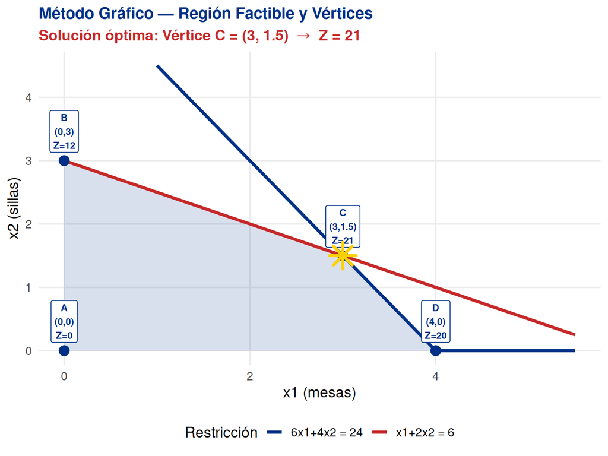

```r
x_v <- seq(0, 5.5, 0.01)
df_r <- rbind(
  data.frame(x1=x_v, x2=pmax(0,(24-6*x_v)/4), res="6x1+4x2 = 24"),
  data.frame(x1=x_v, x2=pmax(0,(6-x_v)/2),    res="x1+2x2 = 6")
)
region <- data.frame(x1=c(0,0,3,4,0), x2=c(0,3,1.5,0,0))
opt    <- vertices[idx_opt,]

ggplot() +
  geom_polygon(data=region, aes(x1,x2),
               fill="#003087", alpha=0.15) +
  geom_line(data=df_r, aes(x1,x2,color=res), size=1.4, na.rm=TRUE) +
  geom_point(data=vertices, aes(x1,x2),
             size=4, color="#003087") +
  geom_label(data=vertices,
             aes(x1,x2,
                 label=paste0(Label,"\n(",x1,",",x2,")\nZ=",Z)),
             size=3.2, vjust=-0.2, fill="white",
             color="#003087", fontface="bold", label.padding=unit(0.3,"lines")) +
  geom_point(data=opt, aes(x1,x2),
             size=7, color="#FFD100", shape=8, stroke=2) +
  scale_color_manual(values=c("#003087","#C62828")) +
  labs(title="Método Gráfico — Región Factible y Vértices",
       subtitle=paste0("Solución óptima: Vértice C = (3, 1.5)  →  Z = 21"),
       x="x1 (mesas)", y="x2 (sillas)", color="Restricción") +
  xlim(0,5.5) + ylim(0,4.5) +
  theme_minimal(base_size=14) +
  theme(
    plot.title    = element_text(color="#003087", face="bold", size=15),
    plot.subtitle = element_text(color="#C62828", face="bold"),
    legend.position = "bottom",
    panel.grid.minor = element_blank()
  )
```

**Solución óptima:** $x_1 = 3$ mesas, $x_2 = 1.5$ sillas, **Z máx = $21**

## Cómo graficar en GeoGebra Online

Abre **[GeoGebra Clásico](https://www.geogebra.org/classic?lang=es)** y sigue estos pasos:

Instrucciones paso a paso en GeoGebra

| Paso | Qué_escribir_en_Barra_de_Entrada | Para_qué |
| --- | --- | --- |
| 1 | f(x) = (24 - 6x) / 4 | Grafica la recta de la restricción 1 |
| 2 | g(x) = (6 - x) / 2 | Grafica la recta de la restricción 2 |
| 3 | A=(0,0) B=(0,3) C=(3,1.5) D=(4,0) | Marca los 4 vértices de la región factible |
| 4 | Z(x,y) = 5x + 4y luego evalúa: Z(0,0) Z(0,3) Z(3,1.5) Z(4,0) | Define Z y evalúa en cada vértice |
| 5 | 6x+4y<=24 y x+2y<=6 y y>=0 y x>=0 | Sombrea la región factible (clic derecho → color) |

**Resultado en GeoGebra:** Z(0,0)=0 | Z(0,3)=12 | **Z(3,1.5)=21 ← ÓPTIMO** | Z(4,0)=20

# 3.3 Método Simplex — Solución Completa Paso a Paso

**¿Cuándo usar Simplex?** Cuando el problema tiene más de 2 variables o restricciones y ya no se puede graficar. Las ecuaciones algebraicas y las tablas del método tabular son EQUIVALENTES.

## Problema ejemplo completo

**Empresa manufacturera** — Maximizar:

$$Z = 5x_1 + 4x_2 + 3x_3$$

Sujeto a:

$$6x_1 + 4x_2 + 2x_3 \leq 240 \quad
(1)$$
$$3x_1 + 2x_2 + 5x_3 \leq 270
\quad (2)$$
$$5x_1 + 6x_2 + 5x_3 \leq
420 \quad (3)$$
$$x_1, x_2, x_3 \geq
0$$

## PASO 1 — Convertir a Forma Estándar

3 restricciones → agregar **3 variables de holgura** ($s_1, s_2, s_3$):

$$Z = 5x_1 + 4x_2 + 3x_3 + 0s_1 + 0s_2 +
0s_3$$

$$6x_1 + 4x_2 + 2x_3 + s_1 = 240$$
$$3x_1 + 2x_2 + 5x_3 + s_2 = 270$$
$$5x_1 + 6x_2 + 5x_3 + s_3 = 420$$

```
## Solución básica INICIAL (variables no básicas = 0):
```

```
##   x1=0, x2=0, x3=0
```

```
##   s1=240, s2=270, s3=420
```

```
##   Z = 0
```

```
##
## Todas las holguras están en la BASE — ningún recurso se ha usado aún.
```

## PASO 2 — Tabla Inicial (Iteración 0)

Tabla Simplex — Iteración 0 (Z = 0)

| Base | x1 | x2 | x3 | s1 | s2 | s3 | LD |
| --- | --- | --- | --- | --- | --- | --- | --- |
| s1 | 6 | 4 | 2 | 1 | 0 | 0 | 240 |
| s2 | 3 | 2 | 5 | 0 | 1 | 0 | 270 |
| s3 | 5 | 6 | 5 | 0 | 0 | 1 | 420 |
| Z | -5 | -4 | -3 | 0 | 0 | 0 | 0 |

A **Identificar variable ENTRANTE:** columna con mayor valor positivo en |fila Z| → **x1 (coef = 5)**

B **Prueba de razón mínima** (solo filas con coef > 0 en columna pivote):

Prueba de razón mínima — Iteración 0

| Fila | LD | Coef. x1 | Razón LD/Coef |
| --- | --- | --- | --- |
| s1 | 240 | 6 | 240/6 = 40 |
| s2 | 270 | 3 | 270/3 = 90 |
| s3 | 420 | 5 | 420/5 = 84 |

**Razón mínima = 40 (fila s1)** → **s1 sale de la base**, x1 entra. El elemento PIVOTE es 6 (fila s1, columna x1).

## PASO 3 — Operaciones de Pivoteo (Iter. 0 → Iter. 1)

**Operación pivote:** el elemento pivote es **6** (fila s1, columna x1).

```
## Nueva fila x1 = fila s1 / 6:
```

```
##   [6,4,2,1,0,0,240] / 6 = [1, 2/3, 1/3, 1/6, 0, 0, 40]
```

```
## Actualizar fila s2: fila s2 - 3*(nueva fila x1):
```

```
##   [3,2,5,0,1,0,270] - 3*[1,2/3,1/3,1/6,0,0,40]
```

```
##   = [0, 0, 4, -1/2, 1, 0, 150]
```

```
## Actualizar fila s3: fila s3 - 5*(nueva fila x1):
```

```
##   [5,6,5,0,0,1,420] - 5*[1,2/3,1/3,1/6,0,0,40]
```

```
##   = [0, 8/3, 10/3, -5/6, 0, 1, 220]
```

```
## Actualizar fila Z: fila Z + 5*(nueva fila x1):
```

```
##   [-5,-4,-3,0,0,0,0] + 5*[1,2/3,1/3,1/6,0,0,40]
```

```
##   = [0, -2/3, -4/3, 5/6, 0, 0, 200]
```

## PASO 4 — Tabla Iteración 1

Tabla Simplex — Iteración 1 (Z = 200)

| Base | x1 | x2 | x3 | s1 | s2 | s3 | LD |
| --- | --- | --- | --- | --- | --- | --- | --- |
| x1 | 1 | 0.6667 | 0.3333 | 0.1667 | 0 | 0 | 40 |
| s2 | 0 | 0.0000 | 4.0000 | -0.5000 | 1 | 0 | 150 |
| s3 | 0 | 2.6667 | 3.3333 | -0.8333 | 0 | 1 | 220 |
| Z | 0 | -0.6667 | -1.3333 | 0.8333 | 0 | 0 | 200 |

A **¿Hay coeficientes negativos en fila Z?** Sí: x2 = -2/3, x3 = -4/3 → el mayor en valor absoluto es **x3 (-4/3)** → x3 ENTRA.

Prueba de razón mínima — Iteración 1

| Fila | LD | Coef. x3 | Razón LD/Coef |
| --- | --- | --- | --- |
| x1 | 40 | 0.3333 | 40/(1/3) = 120 |
| s2 | 150 | 4.0000 | 150/4 = 37.5 |
| s3 | 220 | 3.3333 | 220/(10/3) = 66 |

**Razón mínima = 37.5 (fila s2)** → **s2 sale de la base**, x3 entra. Pivote = 4.

## PASO 5 — Tabla Iteración 2

Tabla Simplex — Iteración 2

[output not shown]

```
## Fila Z iteración 2:
```

```
##   x2 = 0.6666
```

```
##   Z  = 250
```

[output not shown]

## PASO 6 — Verificar Optimalidad

**Criterio de optimalidad:** el algoritmo Simplex termina cuando TODOS los coeficientes de la fila Z son ≥ 0 (en maximización). En ese momento la solución actual es la óptima.

Verificación de optimalidad — Iteración 2

[output not shown]

## PASO 7 — Leer la Solución Óptima

Solución Óptima Final

| Variable | Valor Óptimo | Interpretación |
| --- | --- | --- |
| x1 | 27.5012 | Unidades del producto 1 a fabricar |
| x2 | 0.0000 | No se fabrica (no es rentable en este óptimo) |
| x3 | 37.5000 | Unidades del producto 3 a fabricar |
| s1 | 0.0000 | Recurso 1 agotado (holgura = 0) |
| s2 | 0.0000 | Recurso 2 agotado (holgura = 0) |
| s3 | 95.0012 | 95 unidades del recurso 3 sin usar |
| Z | 250.0000 | GANANCIA MÁXIMA |

Se usan completamente los recursos 1 y 2 (s1=0, s2=0). Quedan 220−125=95 unidades del recurso 3 sin utilizar.

## Resumen del proceso Simplex

Historial de iteraciones del Simplex

| Iteración | Variables en Base | Z | Entra | Sale |
| --- | --- | --- | --- | --- |
| 0 (inicial) | s1, s2, s3 | 0 | x1 | s1 |
| 1 | x1, s2, s3 | 200 | x3 | s2 |
| 2 (óptima) | x1, x3, s3 | 250 | — | — |

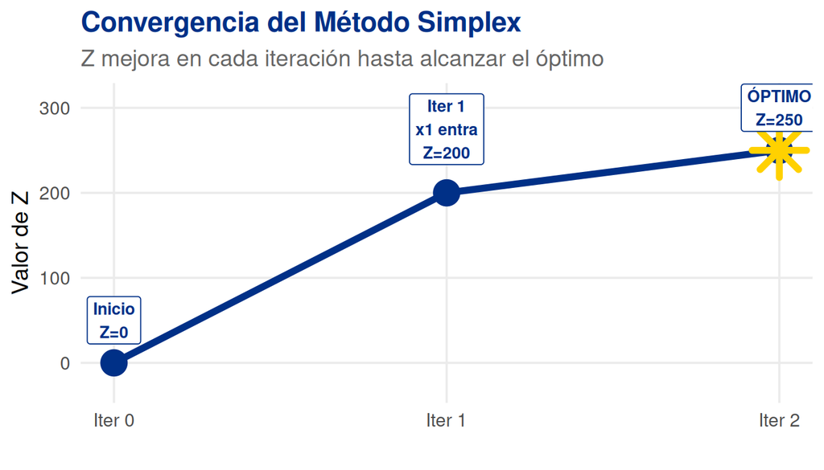

```r
iters <- data.frame(
  iter=0:2,
  Z=c(0, 200, round(Z_opt,2)),
  lab=c("Inicio\nZ=0","Iter 1\nx1 entra\nZ=200",paste0("ÓPTIMO\nZ=",round(Z_opt,2)))
)
ggplot(iters, aes(iter,Z)) +
  geom_line(color="#003087", size=2) +
  geom_point(size=7, color="#003087") +
  geom_point(data=iters[3,], aes(iter,Z), size=9,
             color="#FFD100", shape=8, stroke=3) +
  geom_label(aes(label=lab), vjust=-0.4, size=3.5,
             fill="white", color="#003087", fontface="bold",
             label.padding=unit(0.3,"lines")) +
  scale_x_continuous(breaks=0:2, labels=c("Iter 0","Iter 1","Iter 2")) +
  labs(title="Convergencia del Método Simplex",
       subtitle="Z mejora en cada iteración hasta alcanzar el óptimo",
       x="", y="Valor de Z") +
  ylim(-30, round(Z_opt*1.25)) +
  theme_minimal(base_size=14) +
  theme(
    plot.title    = element_text(color="#003087", face="bold"),
    plot.subtitle = element_text(color="#666"),
    panel.grid.minor = element_blank()
  )
```

# 3.4 Casos Especiales

## 3.4.1 No acotamiento

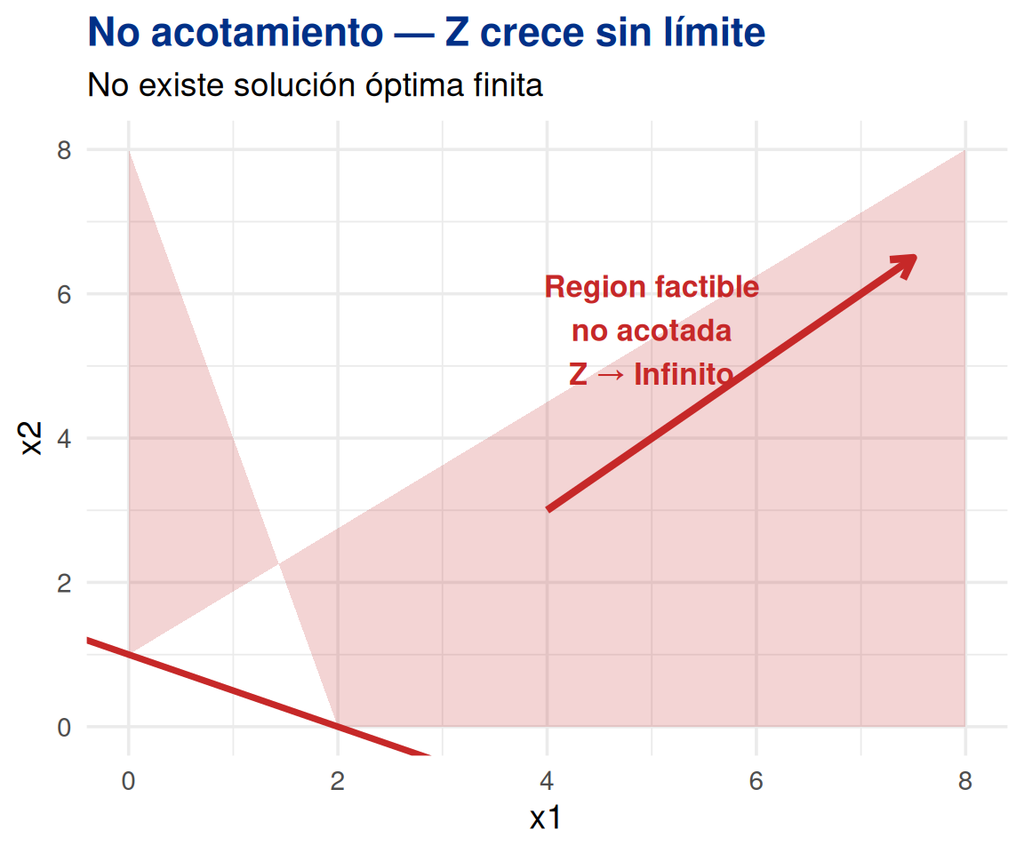

```r
region_na <- data.frame(x=c(0,0,2,8,8), y=c(1,8,0,0,8))
ggplot() +
  geom_polygon(data=region_na, aes(x,y), fill="#C62828", alpha=0.2) +
  geom_abline(intercept=1, slope=-0.5, color="#C62828", size=1.3) +
  annotate("text",x=5,y=5.5,
           label="Region factible\nno acotada\nZ → Infinito",
           size=4.5,color="#C62828",fontface="bold",hjust=0.5) +
  annotate("segment",x=4,xend=7.5,y=3,yend=6.5,
           arrow=arrow(length=unit(0.35,"cm")),
           color="#C62828",size=1.5) +
  labs(title="No acotamiento — Z crece sin límite",
       subtitle="No existe solución óptima finita",
       x="x1",y="x2") +
  xlim(0,8)+ylim(0,8)+
  theme_minimal(base_size=14)+
  theme(plot.title=element_text(color="#003087",face="bold"))
```

**Señal en Simplex:** en la prueba de razón mínima, ningún coeficiente de la columna pivote es positivo → no hay límite superior para Z.

## 3.4.2 Degeneración

Ocurre cuando una **variable básica tiene valor cero**. Z no mejora en esa iteración pero el algoritmo continúa normalmente hasta el óptimo.

## 3.4.3 Convergencia

El Simplex **siempre termina** porque:

1. El número de vértices (soluciones básicas factibles) es **finito**
2. En cada iteración Z **no disminuye**
3. No se visita el mismo vértice dos veces (sin degeneración)

# Resumen de la Semana 5

Resumen Semana 5 — Modelos de Optimización

| Tema | Concepto Clave |
| --- | --- |
| 3.1 | Forma CANÓNICA → tiene DESIGUALDADES (≤) |
| 3.1 | Forma ESTÁNDAR → tiene IGUALDADES (=) |
| 3.1 | Variables de HOLGURA: 1 por cada restricción ≤ |
| 3.2 | Método GRÁFICO: solo con exactamente 2 variables |
| 3.3 | Método SIMPLEX: para más de 2 variables/restricciones |
| 3.3 | Algebraico y tabular son EQUIVALENTES |
| 3.3 | Criterio de optimalidad: todos los coef. de Z ≥ 0 |
| 3.4 | No acotamiento, degeneración, convergencia |

**Próxima semana (Semana 6):** Actividad 5 — resolverás problemas completos con el Método Simplex. Asegúrate de dominar la conversión a forma estándar, la prueba de razón mínima y la lectura de la solución óptima desde la tabla final.

*Prof. Fausto Noé Jiménez | Modelos de Optimización | SABES Campus San Felipe | Mayo–Agosto 2026*